# engsoccerdata FA Cup demo

In this quick tutorial, I shall give a short illustrated example of the sort of question that can be answered using some of the data contained within my `engsoccerdata` package. I picked the following question more or less at random, but it serves our purpose well…

> Let’s say we wanted to know for every season what proportion of teams who got through to the quarter-finals (last eight teams) also did so the following season? This would be one crude and basic way of assessing the ‘competitiveness’ of the competition.

### How do we do this ?

If you haven’t already installed the `engsoccerdata` package, then do that:

```r
library(devtools)
install_github('jalapic/engsoccerdata', username = "jalapic")
```

Next, load the packages we will need and take a look at the `facup` dataset from `engsoccerdata`. Because there are 19 variables and they don’t all fit nicely across the screen, I shall display them in 2 chunks:

```r
#these are the packages that we will need to have loaded for our data munging and graphing:
library(engsoccerdata)
library(dplyr)
library(tidyr)
library(ggplot2)
library(zoo)
```

```r
facup[1:5, 1:14]   #first 5 rows, variables 1-14
```

```
##         date Season                home             visitor  FT hgoal
## 1 1871-11-11   1871              Barnes       Civil Service 2-0     2
## 2 1871-11-11   1871             Hitchin Crystal Palace 1861 0-0     0
## 3 1871-11-11   1871   Maidenhead United              Marlow 2-0     2
## 4 1871-11-11   1871          Upton Park      Clapham Rovers 0-3     0
## 5 1871-12-16   1871 Crystal Palace 1861   Maidenhead United 3-0     3
##   vgoal round     tie  aet  pen pens hp vp
## 1     0     1 initial <NA> <NA> <NA> NA NA
## 2     0     1 initial <NA> <NA> <NA> NA NA
## 3     0     1 initial <NA> <NA> <NA> NA NA
## 4     3     1 initial <NA> <NA> <NA> NA NA
## 5     0     2 initial <NA> <NA> <NA> NA NA
```

These first rows give the date of the match, the season (e.g. 1871 refers to 1871/72), the home team, the visiting team, & the final score (regardless of whether this was after 90 minutes or extra time). The final two variables refer to the number of goals scored by the teams in the home and visitor variables respectively.

The next column refers to the round of the match. This can be 1 to 6, ‘s’ for semi, ‘f’ for final or ‘3pp’ for third-place playoff (which only occurred 1970/1-1973/4). The ‘tie’ variable refers to whether the game is an initial tie (first meeting in that round), a replay or something else (a bye, walkover or void match). The final five variables here refer to penalty shoot-outs but that isn’t important right now.

```r
facup[1:5, 15:19]  #first 5 rows, variables 6-13
```

```
##                    Venue attendance nonmatch
## 1                   <NA>      1,200     <NA>
## 2     Top Field, Hitchin        750     <NA>
## 3  York Road, Maidenhead      1,287     <NA>
## 4  West Ham Park, London      1,500     <NA>
## 5 Crystal Palace, London       <NA>     <NA>
##                            notes neutral
## 1                           <NA>    <NA>
## 2 No replay, both teams progress    <NA>
## 3                           <NA>    <NA>
## 4                           <NA>    <NA>
## 5                           <NA>    <NA>
```

These variables refer to the venue, attendance and other notes and details regarding the circumstances of the individual game. This isn’t important either right now.

Because we are interested in the last eight teams each season, we should take a look at how many teams are in each round in each year. To do this, I will only look at initial ties. This will produce quite a lot of output, but it’s probably worth reproducing all of it for this purpose:

```r
facup.i <- facup %>% filter(tie=="initial")
table(facup.i$round, facup.i$Season)
```

```
##
##       1871 1872 1873 1874 1875 1876 1877 1878 1879 1880 1881 1882 1883
##   1      6    7   14   14   16   18   21   21   26   31   36   39   48
##   2      5    3    7    7    8    9   11   11   13   13   16   20   24
##   3      2    2    3    4    4    5    5    5    5    6    7   10   11
##   3pp    0    0    0    0    0    0    0    0    0    0    0    0    0
##   4      0    1    0    0    0    2    3    3    5    6    7    7    8
##   5      0    0    0    0    0    0    0    0    2    3    3    4    4
##   6      0    0    0    0    0    0    0    0    0    0    0    0    0
##   f      1    1    1    1    1    1    1    1    1    1    1    1    1
##   s      3    1    2    2    2    1    1    1    1    1    2    2    2
##
##       1884 1885 1886 1887 1888 1889 1890 1891 1892 1893 1894 1895 1896
##   1     55   65   62   73   16   16   13   16   16   16   16   16   16
##   2     27   32   31   35    8    8    8    8    8    8    8    8    8
##   3     13   15   16   18    4    4    4    4    4    4    4    4    4
##   3pp    0    0    0    0    0    0    0    0    0    0    0    0    0
##   4      9    2    3    7    0    0    0    0    0    0    0    0    0
##   5      1    8    8    8    0    0    0    0    0    0    0    0    0
##   6      4    4    4    4    0    0    0    0    0    0    0    0    0
##   f      1    1    1    1    1    1    1    1    1    1    1    1    1
##   s      2    2    2    2    2    2    2    2    2    2    2    2    2
##
##       1897 1898 1899 1900 1901 1902 1903 1904 1905 1906 1907 1908 1909
##   1     16   16   16   16   16   16   16   16   32   32   32   32   32
##   2      8    8    8    8    8    8    8    8   16   16   16   16   16
##   3      4    4    4    4    4    4    4    4    8    8    8    8    8
##   3pp    0    0    0    0    0    0    0    0    0    0    0    0    0
##   4      0    0    0    0    0    0    0    0    4    4    4    4    4
##   5      0    0    0    0    0    0    0    0    0    0    0    0    0
##   6      0    0    0    0    0    0    0    0    0    0    0    0    0
##   f      1    1    1    1    1    1    1    1    1    1    1    1    1
##   s      2    2    2    2    2    2    2    2    2    2    2    2    2
##
##       1910 1911 1912 1913 1914 1919 1920 1921 1922 1923 1924 1925 1926
##   1     32   32   32   32   32   32   32   32   32   32   32   38   38
##   2     16   16   16   16   16   16   16   16   16   16   16   19   19
##   3      8    8    8    8    8    8    8    8    8    8    8   32   32
##   3pp    0    0    0    0    0    0    0    0    0    0    0    0    0
##   4      4    4    4    4    4    4    4    4    4    4    4   16   16
```

[output cut: 66 more lines]

```
##   5      8    8    8    8    8    8    8    8    8    8    8    8    8
##   6      4    4    4    4    4    4    4    4    4    4    4    4    4
##   f      1    1    1    1    1    1    1    1    1    1    1    1    1
##   s      2    2    2    2    2    2    2    2    2    2    2    2    2
##
##       2011 2012 2013
##   1     40   40   40
##   2     20   20   20
##   3     32   32   32
##   3pp    0    0    0
##   4     16   16   16
##   5      8    8    8
##   6      4    4    4
##   f      1    1    1
##   s      2    2    2
```

Going backwards in time, it’s pretty clear that the format is quite orderly from 1946/47 to 2013/14 and that the 6th round has 4 ties (8 teams) in it for each season during this stretch. In 1945 there was a different format (we’ll return to that in a minute). The 6th round also consisted of 4 ties from 1925/26 - 1938/39. From 1905/06 - 1924/25 it was the 4th round that had 4 ties. From 1888/89 to 1904/05 it was the 3rd round. From 1885/86 - 1887/88 it was the 6th round again with 4 ties. I won’t bother in this tutorial with looking prior to the 1885/86 season as the format was very unwieldy earlier than this.

```r
facup.45 <- facup %>% filter(Season==1945)
table(facup.45$round, facup.45$tie)
```

```
##
##     initial leg1 leg2 replay
##   1       0   34   34      0
##   2       0   17   17      0
##   3       0   32   32      2
##   4       0   16   16      1
##   5       0    8    8      0
##   6       0    4    4      0
##   f       1    0    0      0
##   s       2    0    0      1
```

Next we shall use `dplyr` and `tidyr` to collate all the rounds/seasons we need to answer our question. Each series of commands filters the seasons/rounds/ties of interest before creating a neat, two-variable df consisting of ‘season’ and ‘team’:

```r
#1946/47 - 2013/14
df1<-facup %>%
  filter(Season<=2013 & Season>=1946) %>%
  filter(tie=="initial" & round=="6") %>%
  select(Season,home,visitor) %>%
  gather(key,team,2:3) %>%
  select(Season,team) %>%
  arrange(Season,team)


#1945/46
df2<-facup %>%
  filter(Season==1945) %>%
  filter(tie=="leg1" & round=="6") %>%
  select(Season,home,visitor) %>%
  gather(key,team,2:3) %>%
  select(Season,team) %>%
  arrange(Season,team)


#1925/26 - 1938/39
df3<-facup %>%
  filter(Season<=1938 & Season>=1925) %>%
  filter(tie=="initial" & round=="6") %>%
  select(Season,home,visitor) %>%
  gather(key,team,2:3) %>%
  select(Season,team) %>%
  arrange(Season,team)


#1905/06 - 1924/25
df4<-facup %>%
  filter(Season<=1924 & Season>=1905) %>%
  filter(tie=="initial" & round=="4") %>%
  select(Season,home,visitor) %>%
  gather(key,team,2:3) %>%
  select(Season,team) %>%
  arrange(Season,team)


#1888/89 - 1904/05
df5<-facup %>%
  filter(Season<=1904 & Season>=1888) %>%
  filter(tie=="initial" & round=="3") %>%
  select(Season,home,visitor) %>%
  gather(key,team,2:3) %>%
  select(Season,team) %>%
  arrange(Season,team)


#1885/86 - 1887/88
df6<-facup %>%
  filter(Season<=1887 & Season>=1885) %>%
  filter(tie=="initial" & round=="6") %>%
  select(Season,home,visitor) %>%
  gather(key,team,2:3) %>%
  select(Season,team) %>%
  arrange(Season,team)
```

To give an example of what each of these looks like, here are the first 16 rows of ‘df1’. You can see here that ‘Preston North End’ were the only team to appear in both 1946/47 and 1947/48:

```r
head(df1,16)
```

```
##    Season                team
## 1    1946     Birmingham City
## 2    1946             Burnley
## 3    1946   Charlton Athletic
## 4    1946           Liverpool
## 5    1946       Middlesbrough
## 6    1946    Newcastle United
## 7    1946   Preston North End
## 8    1946    Sheffield United
## 9    1947           Blackpool
## 10   1947        Derby County
## 11   1947              Fulham
## 12   1947   Manchester United
## 13   1947   Preston North End
## 14   1947 Queens Park Rangers
## 15   1947         Southampton
## 16   1947   Tottenham Hotspur
```

Now we simply bind all of these together and we have our dataframe of ‘last 8’ teams for 1885/86 - 2013/14…

```r
last8 <- rbind(df6,df5,df4,df3,df2,df1)
head(last8)
```

```
##   Season             team
## 1   1885  Birmingham City
## 2   1885 Blackburn Rovers
## 3   1885        Brentwood
## 4   1885 Old Westminsters
## 5   1885           Redcar
## 6   1885      South Shore
```

Now for the slightly tricky bit. We need to work out the difference in the number of teams from one season to the next. Fortunately this is made easy by using the `setdiff` function. I’m going to run a `for loop` for this, there are probably better ways, but this method is quite easy to deconstruct to illustrate what is going on. Here, I will build up the steps:

First create a list of each set of 8 teams using `split` on season:

```r
last8.l <- split(last8, last8$Season)
```

```r
last8.l[[3]]
```

```
##    Season                 team
## 17   1887     Blackburn Rovers
## 18   1887      Crewe Alexandra
## 19   1887       Derby Junction
## 20   1887        Middlesbrough
## 21   1887      Old Carthusians
## 22   1887    Preston North End
## 23   1887  Sheffield Wednesday
## 24   1887 West Bromwich Albion
```

```r
last8.l[[3]][,2] #this just returns a vector of teams, i.e. the 2nd variable
```

```
## [1] "Blackburn Rovers"     "Crewe Alexandra"      "Derby Junction"
## [4] "Middlesbrough"        "Old Carthusians"      "Preston North End"
## [7] "Sheffield Wednesday"  "West Bromwich Albion"
```

```r
last8.l[[4]][,2] #this returns a vector of teams from the following season
```

```
## [1] "Aston Villa"             "Birmingham St George's"
## [3] "Blackburn Rovers"        "Chatham"
## [5] "Preston North End"       "Sheffield Wednesday"
## [7] "West Bromwich Albion"    "Wolverhampton Wanderers"
```

Now get the difference between these lists:

```r
setdiff(last8.l[[4]][,2] , last8.l[[3]][,2])
```

```
## [1] "Aston Villa"             "Birmingham St George's"
## [3] "Chatham"                 "Wolverhampton Wanderers"
```

```r
length(setdiff(last8.l[[4]][,2] , last8.l[[3]][,2])) #which means that 8-4 = 4 teams were the same
```

```
## [1] 4
```

Let’s put all of that in a loop. We start the loop at the 2nd season as obviously we cannot start at the first as it has no comparison (for the purposes of this tutorial):

```r
results <- NULL #create empty vector

for (i in 2:length(last8.l)){
differences <- length(setdiff(last8.l[[i]][,2] , last8.l[[i-1]][,2]))
results[[i]] <- 8 - differences
}
```

The results show the number of teams in the last 8 who were also in the season before:

```r
results
```

```
##   [1] NA  2  3  4  4  5  6  4  2  4  5  2  4  5  4  3  1  3  2  2  4  4  1
##  [24]  2  1  2  3  2  3  1  2  3  4  1  0  3  0  2  1  3  4  0  1  1  1  3
##  [47]  1  2  4  2  0  2  1  2  2  2  1  1  2  0  4  2  2  1  3  4  3  1  3
##  [70]  2  2  4  4  4  2  1  3  2  0  0  0  3  1  2  4  3  1  0  2  1  4  2
##  [93]  3  3  2  1  2  0  0  2  2  2  0  3  3  1  2  2  2  2  1  3  3  3  2
## [116]  3  2  2  3
```

We can calculate the number of times that every team that has reached the last eight did not the previous year.

```r
sum(results==0, na.rm=T)
```

```
## [1] 12
```

We could also do a simple histogram plot

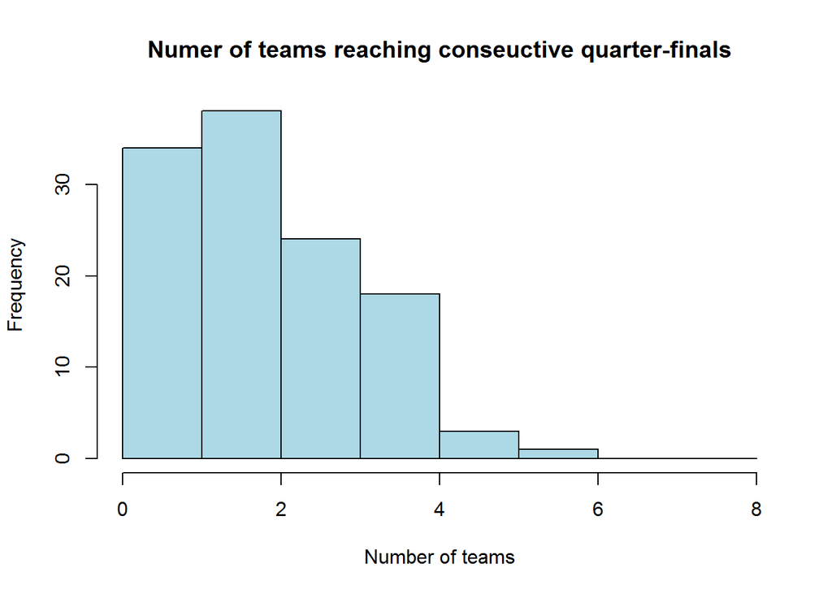

```r
hist(results, col="lightblue", breaks=c(0,1,2,3,4,5,6,7,8), main="Numer of teams reaching conseuctive quarter-finals", xlab="Number of teams")
```

Let’s make that into a dataframe and add season as a varaiable too:

```r
mydf <- data.frame(Season = names(last8.l), sameteams = results)
head(mydf)
```

```
##   Season sameteams
## 1   1885        NA
## 2   1886         2
## 3   1887         3
## 4   1888         4
## 5   1889         4
## 6   1890         5
```

```r
rollapply(mydf$sameteams, width=5, FUN=mean, fill=NA, align=c("right"))  #from library(zoo)
```

```
##   [1]  NA  NA  NA  NA  NA 3.6 4.4 4.6 4.2 4.2 4.2 3.4 3.4 4.0 4.0 3.6 3.4
##  [18] 3.2 2.6 2.2 2.4 3.0 2.6 2.6 2.4 2.0 1.8 2.0 2.2 2.2 2.2 2.2 2.6 2.2
##  [35] 2.0 2.2 1.6 1.2 1.2 1.8 2.0 2.0 1.8 1.8 1.4 1.2 1.4 1.6 2.2 2.4 1.8
##  [52] 2.0 1.8 1.4 1.4 1.8 1.6 1.6 1.6 1.2 1.6 1.8 2.0 1.8 2.4 2.4 2.6 2.4
##  [69] 2.8 2.6 2.2 2.4 3.0 3.2 3.2 3.0 2.8 2.4 1.6 1.2 1.0 1.0 0.8 1.2 2.0
##  [86] 2.6 2.2 2.0 2.0 1.4 1.6 1.8 2.4 2.6 2.8 2.2 2.2 1.6 1.0 1.0 1.2 1.2
## [103] 1.2 1.8 2.0 1.8 1.8 2.2 2.0 1.8 1.8 2.0 2.2 2.4 2.4 2.8 2.6 2.4 2.4
```

```r
mydf$movavg <- rollapply(mydf$sameteams, width=5, FUN=mean, fill=NA, align=c("right"))  #add into mydf

head(mydf, 10)
```

```
##    Season sameteams movavg
## 1    1885        NA     NA
## 2    1886         2     NA
## 3    1887         3     NA
## 4    1888         4     NA
## 5    1889         4     NA
## 6    1890         5    3.6
## 7    1891         6    4.4
## 8    1892         4    4.6
## 9    1893         2    4.2
## 10   1894         4    4.2
```

Before we graph it, I want to add some years so that gaps will appear along the x-axis for the two World Wars.

```r
setdiff(1885:2013,names(last8.l)) #get those years not included
```

```
##  [1] 1915 1916 1917 1918 1939 1940 1941 1942 1943 1944
```

```r
mydfNA <- data.frame(Season = setdiff(1885:2013, names(last8.l)), sameteams = NA, movavg = NA)  #create a df we can append to mydf

mydf$Season <- as.numeric(as.character(mydf$Season)) #need to make sure that season is a number not a factor


mydf <- rbind(mydf, mydfNA) #this ensures that the war years are gaps when doing a line graph
```

Now let’s plot:

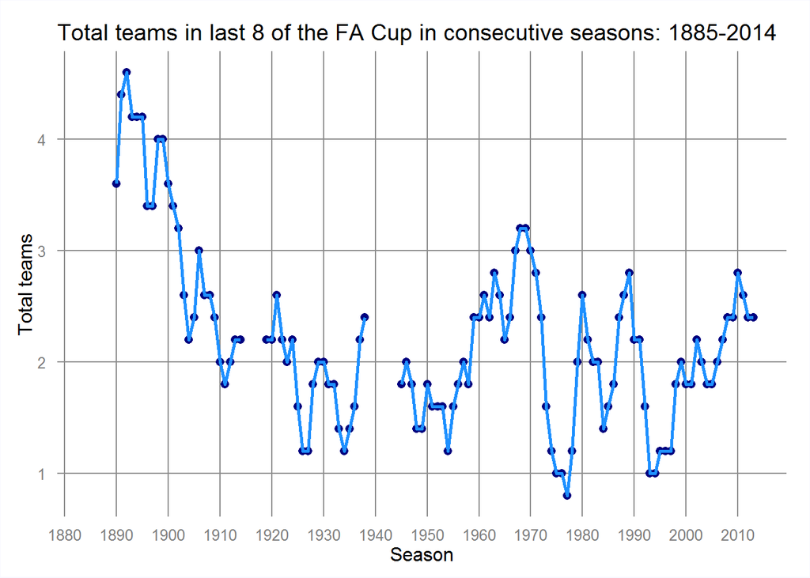

```r
ggplot(mydf, aes(Season, movavg)) +
       geom_point(color="navy", size=2.5) +
       geom_line(aes(group=1), lwd=1, color="dodgerblue") +
         scale_x_continuous(breaks=c(seq(1880,2020,10))) +
       ggtitle("Total teams in last 8 of the FA Cup in consecutive seasons: 1885-2014") +
       ylab("Total teams") +
  theme(
    panel.grid.major.x = element_line(color="gray55"),
    panel.grid.major.y = element_line(color="gray55"),
    axis.ticks.x = element_blank(),
    axis.ticks.y = element_blank(),
    panel.grid.minor = element_blank(),
    plot.background  = element_rect(color = "ghostwhite"),
    panel.background = element_blank(),
    plot.title = element_text(hjust=0,vjust=1)
    )
```

This is just a quick example of how easy it is to turn all of this data into something visually appealing that can stimulate further research questions and ideas.

If you’re interested in this and what to learn more or discuss, please get in touch with me - jc3181 AT columbia DOT edu